# 3-phase controlled rectifier

In the three-phase thyristor rectifier circuit given below, $v_a=220\sqrt 2 \sin(\omega t)$, $v_b=220\sqrt 2 \sin(\omega t-120^\circ)$, and $v_c=220\sqrt 2 \sin(\omega t+120^\circ)$. The converter is operated at a firing angle of $30^{\circ}$. Determine the duration for which each diode will be reverse biased in a fundamental cycle of the input voltage.

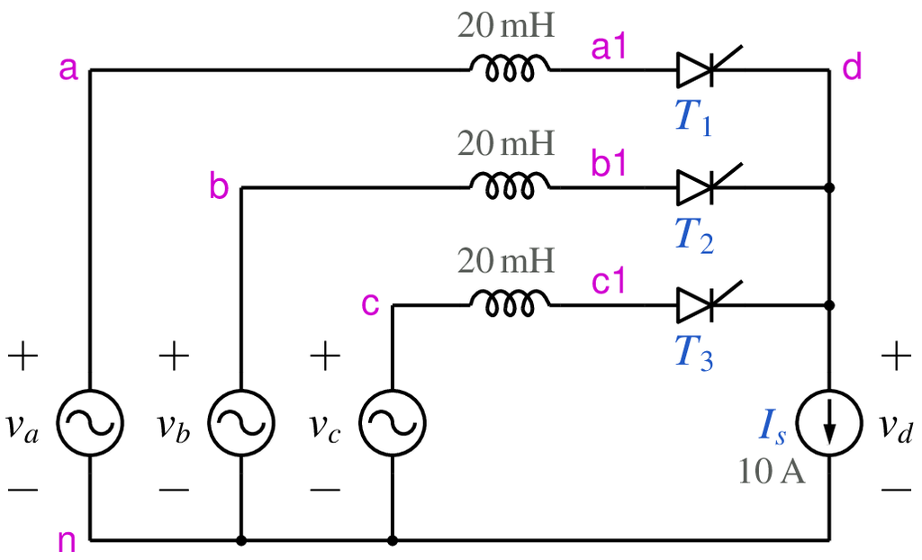

```python
from IPython.display import Image
Image(filename =r'controlled_rectifier_3ph_7_fig_1.png', width=420)
```

```python
# run this cell to view the circuit file.
%pycat controlled_rectifier_3ph_7_orig.in
```

We now replace the strings such as `\$alpha` with the values of our choice by running the python script given below. It takes an existing circuit file `controlled_rectifier_3ph_7_orig.in` and produces a new circuit file `controlled_rectifier_3ph_7.in`, after replacing `\$alpha` (etc) with values of our choice.

```python
import gseim_calc as calc
import numpy as np

s_alpha = "30"
s_L = "20e-3"

A_sin = 220.0*np.sqrt(2.0)
s_A_sin = ("%11.4E"%(A_sin)).strip()

l = [
  ('$alpha', s_alpha),
  ('$L', s_L),
  ('$A_sin', s_A_sin),
]
calc.replace_strings_1("controlled_rectifier_3ph_7_orig.in", "controlled_rectifier_3ph_7.in", l)
print('controlled_rectifier_3ph_7.in is ready for execution')
```

```
controlled_rectifier_3ph_7.in is ready for execution
```

**Execute the following cell to run GSEIM on controlled_rectifier_3ph_7.in.**

```python
import os
import dos_unix
# uncomment for windows:
#dos_unix.d2u("controlled_rectifier_3ph_7.in")
os.system('run_gseim controlled_rectifier_3ph_7.in')
```

```
Circuit: filename = controlled_rectifier_3ph_7.in
main: calling solve_sss
solve_sss starting: sss_n_st: 3
solve_sss_ex: sss_iter_newton=0, rhs_sss_norm=5.7736e+00, sss_period_1_compute=4.0000e-02
solve_sss_ex: sss_iter_newton=1, rhs_sss_norm=0.0000e+00, sss_period_1_compute=4.0000e-02
solve_sss_ex: calling sss_solve_trns_ex for one more trns step
Transient simulation starts...
i=0
i=1000
i=2000
GSEIM: Program completed.
```

```
0
```

The circuit file (`controlled_rectifier_3ph_7.in`) is created in the same directory as that used for launching Jupyter notebook. The last step (i.e., running `GSEIM` on `controlled_rectifier_3ph_7.in`) creates data files called `controlled_rectifier_3ph_7_1.dat`, etc. in the same directory. We can now use the python code below to compute/plot the various quantities of interest.

```
filename: controlled_rectifier_3ph_7_2.dat
filename: controlled_rectifier_3ph_7_3.dat
average value of v_o:  1.9264E+02
```

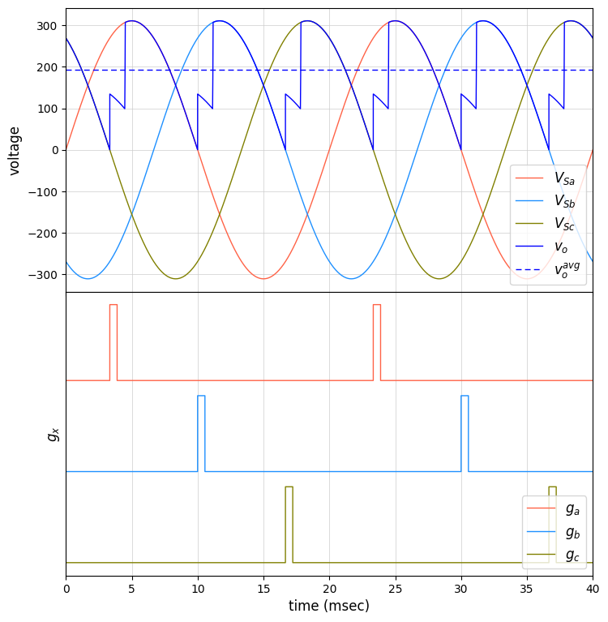

```python
import numpy as np
import matplotlib.pyplot as plt
import gseim_calc as calc
from setsize import set_size

f_hz = 50.0
T = 1.0/f_hz

slv = calc.slv("controlled_rectifier_3ph_7.in")

i_slv = 0
i_out = 1
filename = slv.l_filename_all[i_slv][i_out]
print('filename:', filename)
u1 = np.loadtxt(filename)
t1 = u1[:, 0]

v_o = slv.get_array_double(i_slv,i_out,"v_o",u1)
VSa = slv.get_array_double(i_slv,i_out,"VSa",u1)
VSb = slv.get_array_double(i_slv,i_out,"VSb",u1)
VSc = slv.get_array_double(i_slv,i_out,"VSc",u1)

i_out = 2
filename = slv.l_filename_all[i_slv][i_out]
print('filename:', filename)
u2 = np.loadtxt(filename)
t2 = u2[:, 0]

ga = slv.get_array_double(i_slv,i_out,"ga",u2)
gb = slv.get_array_double(i_slv,i_out,"gb",u2)
gc = slv.get_array_double(i_slv,i_out,"gc",u2)

l_v_o = calc.avg_rms_3a(t1, v_o, 0, 2.0*T, 1.0e-5*T)

print('average value of v_o:', "%11.4E"%l_v_o[0])

fig, ax = plt.subplots(2, sharex=False)
plt.subplots_adjust(wspace=0, hspace=0.0)

set_size(6.5, 7, ax[0])

for i in range(2):
    ax[i].set_xlim(left=0.0, right=2.0*T*1e3)
    ax[i].grid(color='#CCCCCC', linestyle='solid', linewidth=0.5)

ax[0].set_ylabel(r'voltage', fontsize=12)
ax[1].set_ylabel(r'$g_x$'  , fontsize=12)

ax[0].tick_params(labelbottom=False)

color1 = "tomato"
color2 = "dodgerblue"
color3 = "olive"
color4 = "blue"

ax[0].plot(t1*1e3, VSa, color=color1, linewidth=1.0, label="$V_{Sa}$")
ax[0].plot(t1*1e3, VSb, color=color2, linewidth=1.0, label="$V_{Sb}$")
ax[0].plot(t1*1e3, VSc, color=color3, linewidth=1.0, label="$V_{Sc}$")
ax[0].plot(t1*1e3, v_o, color=color4, linewidth=1.0, label="$v_o$")

ax[0].axhline(y=l_v_o[0], color=color4, linewidth=1.0, label="$v_o^{avg}$", linestyle='--', dashes=(5,3))

ax[1].plot(t2*1e3, (ga      ), color=color1, linewidth=1.0, label="$g_a$")
ax[1].plot(t2*1e3, (gb - 1.2), color=color2, linewidth=1.0, label="$g_b$")
ax[1].plot(t2*1e3, (gc - 2.4), color=color3, linewidth=1.0, label="$g_c$")

ax[1].set_xlabel('time (msec)', fontsize=12)
ax[1].tick_params(left = False)
ax[1].set_yticks([])

for i in range(2):
    ax[i].legend(loc = 'lower right',frameon = True, fontsize = 10, title = None,
      markerfirst = True, markerscale = 1.0, labelspacing = 0.5, columnspacing = 2.0,
      prop = {'size' : 12})

#plt.tight_layout()
plt.show()
```

```
filename: controlled_rectifier_3ph_7_1.dat
```

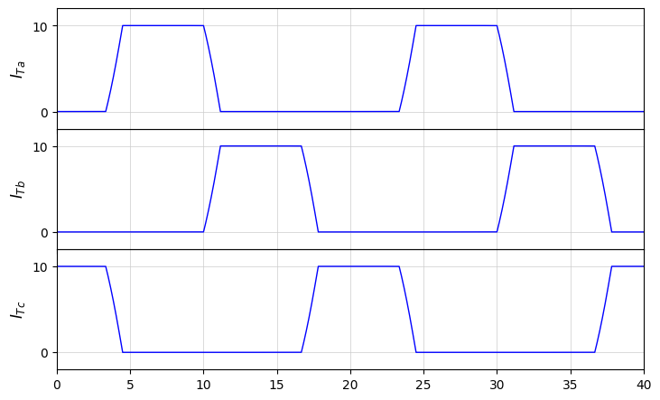

```python
import numpy as np
import matplotlib.pyplot as plt
import gseim_calc as calc
from setsize import set_size

f_hz = 50.0
T = 1.0/f_hz

slv = calc.slv("controlled_rectifier_3ph_7.in")

i_slv = 0
i_out = 0
filename = slv.l_filename_all[i_slv][i_out]
print('filename:', filename)
u1 = np.loadtxt(filename)
t1 = u1[:, 0]

ITa = slv.get_array_double(i_slv,i_out,"ITa",u1)
ITb = slv.get_array_double(i_slv,i_out,"ITb",u1)
ITc = slv.get_array_double(i_slv,i_out,"ITc",u1)

fig, ax = plt.subplots(3, sharex=False)
plt.subplots_adjust(wspace=0, hspace=0.0)

set_size(6.5, 4, ax[0])

for i in range(3):
    ax[i].set_xlim(left=0.0, right=2.0*T*1e3)
    ax[i].grid(color='#CCCCCC', linestyle='solid', linewidth=0.5)
    ax[i].set_yticks([0.0, 10.0])
    ax[i].set_ylim(bottom=-2.0, top=12.0)

ax[0].set_ylabel(r'$I_{Ta}$', fontsize=12)
ax[1].set_ylabel(r'$I_{Tb}$', fontsize=12)
ax[2].set_ylabel(r'$I_{Tc}$', fontsize=12)

for k in range(2):
    ax[k].tick_params(labelbottom=False)

color1 = "blue"

ax[0].plot(t1*1e3, ITa, color=color1, linewidth=1.0, label="$I_{Ta}$")
ax[1].plot(t1*1e3, ITb, color=color1, linewidth=1.0, label="$I_{Tb}$")
ax[2].plot(t1*1e3, ITc, color=color1, linewidth=1.0, label="$I_{Tc}$")

#plt.tight_layout()
plt.show()
```

```
filename: controlled_rectifier_3ph_7_1.dat
angle of reverse bias for Ta:  189.50 deg.
angle of reverse bias for Tb:  189.65 deg.
angle of reverse bias for Tc:  189.50 deg.
```

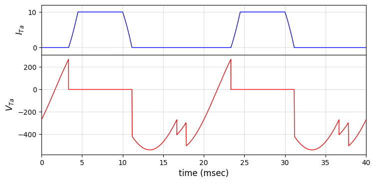

```python
import numpy as np
import matplotlib.pyplot as plt
import gseim_calc as calc
from setsize import set_size

f_hz = 50.0
T = 1.0/f_hz

slv = calc.slv("controlled_rectifier_3ph_7.in")

i_slv = 0
i_out = 0
filename = slv.l_filename_all[i_slv][i_out]
print('filename:', filename)
u1 = np.loadtxt(filename)
t1 = u1[:, 0]

ITa  = slv.get_array_double(i_slv,i_out,"ITa",u1)
v_Ta = slv.get_array_double(i_slv,i_out,"v_Ta",u1)
v_Tb = slv.get_array_double(i_slv,i_out,"v_Tb",u1)
v_Tc = slv.get_array_double(i_slv,i_out,"v_Tc",u1)

# compute durations of reverse bias:

ndiv = 5000

delt_v_Ta, v_Tap = calc.interp_linear_1(t1, v_Ta, ndiv)
delt_v_Tb, v_Tbp = calc.interp_linear_1(t1, v_Tb, ndiv)
delt_v_Tc, v_Tcp = calc.interp_linear_1(t1, v_Tc, ndiv)

n_v_Ta = 0
n_v_Tb = 0
n_v_Tc = 0

for k in range(ndiv):
    if (v_Tap[k] < 0.0): n_v_Ta += 1
    if (v_Tbp[k] < 0.0): n_v_Tb += 1
    if (v_Tcp[k] < 0.0): n_v_Tc += 1

print('angle of reverse bias for Ta:', "%7.2f"%(float(n_v_Ta)*delt_v_Ta*360.0/(2.0*T)), 'deg.')
print('angle of reverse bias for Tb:', "%7.2f"%(float(n_v_Tb)*delt_v_Tb*360.0/(2.0*T)), 'deg.')
print('angle of reverse bias for Tc:', "%7.2f"%(float(n_v_Tc)*delt_v_Tc*360.0/(2.0*T)), 'deg.')

fig, ax = plt.subplots(2, sharex=False,  gridspec_kw={'height_ratios': [1, 2]})
plt.subplots_adjust(wspace=0, hspace=0.0)

set_size(6.5, 3, ax[0])

for i in range(2):
    ax[i].set_xlim(left=0.0, right=2.0*T*1e3)
    ax[i].grid(color='#CCCCCC', linestyle='solid', linewidth=0.5)

ax[0].set_yticks([0.0, 10.0])
ax[0].set_ylim(bottom=-2.0, top=12.0)
ax[0].tick_params(labelbottom=False)

ax[0].set_ylabel(r'$I_{Ta}$', fontsize=12)
ax[1].set_ylabel(r'$V_{Ta}$', fontsize=12)

color1 = "blue"
color2 = "red"

ax[0].plot(t1*1e3, ITa , color=color1, linewidth=1.0, label="$I_{Ta}$")
ax[1].plot(t1*1e3, v_Ta, color=color2, linewidth=1.0, label="$V_{Ta}$")

ax[1].set_xlabel('time (msec)', fontsize=12)

#plt.tight_layout()
plt.show()
```

This notebook was contributed by **Prof. Nakul Narayanan K**, Govt. Engineering College, Thrissur. He may be contacted at nakul@gectcr.ac.in.